# R Notebook

```r
rm(list = ls())

library(Lahman)
library(mosaic)
library(tidyr)
library(tidyverse)
library(dplyr)
library(mplot)
library(ggplot2)
library(cluster)
library(factoextra)
library(corrplot)
library(data.table)
library(mod)
library(modelr)
library(leaps)
library(caret)
library(ISLR2)
library(ggcorrplot)
library(glmnet)
library(dendextend)
```

```r
#Load in People, Batting, and Pitching Dataframes
data("People")
data("Batting")
data("Pitching")
data("Salaries")
```

```r
#Looking at vars in all data frames
names(People)
```

```
 [1] "playerID"     "birthYear"    "birthMonth"
 [4] "birthDay"     "birthCountry" "birthState"
 [7] "birthCity"    "deathYear"    "deathMonth"
[10] "deathDay"     "deathCountry" "deathState"
[13] "deathCity"    "nameFirst"    "nameLast"
[16] "nameGiven"    "weight"       "height"
[19] "bats"         "throws"       "debut"
[22] "finalGame"    "retroID"      "bbrefID"
[25] "deathDate"    "birthDate"
```

```r
names(Batting)
```

```
 [1] "playerID" "yearID"   "stint"    "teamID"
 [5] "lgID"     "G"        "AB"       "R"
 [9] "H"        "X2B"      "X3B"      "HR"
[13] "RBI"      "SB"       "CS"       "BB"
[17] "SO"       "IBB"      "HBP"      "SH"
[21] "SF"       "GIDP"
```

```r
names(Pitching)
```

```
 [1] "playerID" "yearID"   "stint"    "teamID"
 [5] "lgID"     "W"        "L"        "G"
 [9] "GS"       "CG"       "SHO"      "SV"
[13] "IPouts"   "H"        "ER"       "HR"
[17] "BB"       "SO"       "BAOpp"    "ERA"
[21] "IBB"      "WP"       "HBP"      "BK"
[25] "BFP"      "GF"       "R"        "SH"
[29] "SF"       "GIDP"
```

```r
names(Salaries)
```

```
[1] "yearID"   "teamID"   "lgID"     "playerID"
[5] "salary"
```

```r
#Looking at years
Pitching%>%
 arrange(yearID)
```

| playerID | yearID | stint | teamID | lgID | W | L | G | GS | CG | SHO | SV | IPouts | H | ER | HR | BB | SO | BAOpp | ERA | IBB | WP | HBP | BK | BFP | GF | R | SH | SF | GIDP |
| --- | --- | --- | --- | --- | --- | --- | --- | --- | --- | --- | --- | --- | --- | --- | --- | --- | --- | --- | --- | --- | --- | --- | --- | --- | --- | --- | --- | --- | --- |
| bechtge01 | 1871 | 1 | PH1 | NA | 1 | 2 | 3 | 3 | 2 | 0 | 0 | 78 | 43 | 23 | 0 | 11 | 1 | NA | 7.96 | NA | 7 | NA | 0 | 146 | 0 | 42 | NA | NA | NA |
| brainas01 | 1871 | 1 | WS3 | NA | 12 | 15 | 30 | 30 | 30 | 0 | 0 | 792 | 361 | 132 | 4 | 37 | 13 | NA | 4.50 | NA | 7 | NA | 0 | 1291 | 0 | 292 | NA | NA | NA |
| fergubo01 | 1871 | 1 | NY2 | NA | 0 | 0 | 1 | 0 | 0 | 0 | 0 | 3 | 8 | 3 | 0 | 0 | 0 | NA | 27.00 | NA | 2 | NA | 0 | 14 | 0 | 9 | NA | NA | NA |
| fishech01 | 1871 | 1 | RC1 | NA | 4 | 16 | 24 | 24 | 22 | 1 | 0 | 639 | 295 | 103 | 3 | 31 | 15 | NA | 4.35 | NA | 20 | NA | 0 | 1080 | 1 | 257 | NA | NA | NA |
| fleetfr01 | 1871 | 1 | NY2 | NA | 0 | 1 | 1 | 1 | 1 | 0 | 0 | 27 | 20 | 10 | 0 | 3 | 0 | NA | 10.00 | NA | 0 | NA | 0 | 57 | 0 | 21 | NA | NA | NA |
| flowedi01 | 1871 | 1 | TRO | NA | 0 | 0 | 1 | 0 | 0 | 0 | 0 | 3 | 1 | 0 | 0 | 0 | 0 | NA | 0.00 | NA | 0 | NA | 0 | 3 | 1 | 0 | NA | NA | NA |
| mackde01 | 1871 | 1 | RC1 | NA | 0 | 1 | 3 | 1 | 1 | 0 | 0 | 39 | 20 | 5 | 0 | 3 | 1 | NA | 3.46 | NA | 1 | NA | 0 | 70 | 1 | 30 | NA | NA | NA |
| mathebo01 | 1871 | 1 | FW1 | NA | 6 | 11 | 19 | 19 | 19 | 1 | 0 | 507 | 261 | 97 | 5 | 21 | 17 | NA | 5.17 | NA | 15 | NA | 2 | 876 | 0 | 243 | NA | NA | NA |
| mcbridi01 | 1871 | 1 | PH1 | NA | 18 | 5 | 25 | 25 | 25 | 0 | 0 | 666 | 285 | 113 | 3 | 40 | 15 | NA | 4.58 | NA | 3 | NA | 0 | 1059 | 0 | 223 | NA | NA | NA |
| mcmuljo01 | 1871 | 1 | TRO | NA | 12 | 15 | 29 | 29 | 28 | 0 | 0 | 747 | 430 | 153 | 4 | 75 | 12 | NA | 5.53 | NA | 44 | NA | 0 | 1334 | 0 | 362 | NA | NA | NA |

[output cut: 990 more lines]

```r
#Merges player name to Batting data.
bstats <- battingStats()
    str(bstats)
```

```
'data.frame':   108789 obs. of  29 variables:
 $ playerID: chr  "abercda01" "addybo01" "allisar01" "allisdo01" ...
 $ yearID  : int  1871 1871 1871 1871 1871 1871 1871 1871 1871 1871 ...
 $ stint   : int  1 1 1 1 1 1 1 1 1 1 ...
 $ teamID  : Factor w/ 149 levels "ALT","ANA","ARI",..: 136 111 39 142 111 56 111 24 56 24 ...
 $ lgID    : Factor w/ 7 levels "AA","AL","FL",..: 4 4 4 4 4 4 4 4 4 4 ...
 $ G       : int  1 25 29 27 25 12 1 31 1 18 ...
 $ AB      : int  4 118 137 133 120 49 4 157 5 86 ...
 $ R       : int  0 30 28 28 29 9 0 66 1 13 ...
 $ H       : int  0 32 40 44 39 11 1 63 1 13 ...
 $ X2B     : int  0 6 4 10 11 2 0 10 1 2 ...
 $ X3B     : int  0 0 5 2 3 1 0 9 0 1 ...
 $ HR      : int  0 0 0 2 0 0 0 0 0 0 ...
 $ RBI     : int  0 13 19 27 16 5 2 34 1 11 ...
 $ SB      : int  0 8 3 1 6 0 0 11 0 1 ...
 $ CS      : int  0 1 1 1 2 1 0 6 0 0 ...
 $ BB      : int  0 4 2 0 2 0 1 13 0 0 ...
 $ SO      : int  0 0 5 2 1 1 0 1 0 0 ...
 $ IBB     : int  NA NA NA NA NA NA NA NA NA NA ...
 $ HBP     : int  NA NA NA NA NA NA NA NA NA NA ...
 $ SH      : int  NA NA NA NA NA NA NA NA NA NA ...
 $ SF      : int  NA NA NA NA NA NA NA NA NA NA ...
```

[output not shown]

```
 $ GIDP    : int  0 0 1 0 0 0 0 1 0 0 ...
 $ BA      : num  0 0.271 0.292 0.331 0.325 0.224 0.25 0.401 0.2 0.151 ...
 $ PA      : num  4 122 139 133 122 49 5 170 5 86 ...
 $ TB      : num  0 38 54 64 56 15 1 91 2 17 ...
 $ SlugPct : num  0 0.322 0.394 0.481 0.467 0.306 0.25 0.58 0.4 0.198 ...
 $ OBP     : num  0 0.295 0.302 0.331 0.336 0.224 0.4 0.447 0.2 0.151 ...
 $ OPS     : num  0 0.617 0.696 0.812 0.803 ...
 $ BABIP   : num  0 0.271 0.303 0.326 0.328 0.229 0.25 0.404 0.2 0.151 ...
```

```r
People$name <- paste(People$nameFirst, People$nameLast, sep = " ")

batting_name <- merge(Batting,
                 People[,c("playerID", "name")],
                 by = "playerID", all.x = TRUE)

#Merges player name to Pitching data.

People$name <- paste(People$nameFirst, People$nameLast, sep = " ")

pitching_name <- merge(Pitching,
                 People[,c("playerID", "name")],
                 by = "playerID", all.x = TRUE)
```

```r
#Creating additional stats for bstats
bstats[is.na(bstats)] = 0
#bstats <- na.omit(bstats)
#is.nan(bstats)

bstats <- bstats %>%
  mutate(K_Percent = SO / PA) %>%
  mutate(BB_Percent = (BB + IBB) / PA) %>%
  mutate_all(~replace(., is.nan(.), 0))
```

```
invalid factor level, NA generatedinvalid factor level, NA generated
```

```r
bstats <- bstats %>%
  mutate_at(vars(K_Percent, BB_Percent), funs(round(., 3)))
```

```r
bstats_salary <- bstats %>%
              filter(yearID >= 1985) %>%
              left_join(select(Salaries, playerID, yearID, teamID, salary),
                         by=c("playerID", "yearID", "teamID"))

bstats_salary[is.na(bstats_salary)] = 0
#bstats_salary <- na.omit(bstats_salary)
str(bstats_salary)
```

```
'data.frame':   46535 obs. of  32 variables:
 $ playerID  : chr  "aasedo01" "abregjo01" "ackerji01" "adamsri02" ...
 $ yearID    : num  1985 1985 1985 1985 1985 ...
 $ stint     : num  1 1 1 1 1 1 1 1 1 1 ...
 $ teamID    : Factor w/ 149 levels "ALT","ANA","ARI",..: 5 35 134 117 33 102 94 134 134 134 ...
 $ lgID      : Factor w/ 7 levels "AA","AL","FL",..: 2 5 2 5 2 5 5 2 2 2 ...
 $ G         : num  54 6 61 54 54 91 22 12 36 14 ...
 $ AB        : num  0 9 0 121 0 165 36 20 0 34 ...
 $ R         : num  0 0 0 12 0 27 1 2 0 2 ...
 $ H         : num  0 0 0 23 0 46 10 4 0 4 ...
 $ X2B       : num  0 0 0 3 0 7 2 1 0 1 ...
 $ X3B       : num  0 0 0 1 0 3 0 0 0 0 ...
 $ HR        : num  0 0 0 2 0 6 0 1 0 0 ...
 $ RBI       : num  0 1 0 10 0 21 2 5 0 3 ...
 $ SB        : num  0 0 0 1 0 1 0 0 0 0 ...
```

[output cut: 18 more lines]

```r
bstats_sure <- bstats_salary %>%
  filter(PA > 150) %>%
  select(OPS, BABIP, K_Percent, BB_Percent, salary)
```

## Data Preparation (Lesson 1 & 2)

```r
#Keep players with over 150 at bats. (We can change this value if necessary).
#Creating batting average variable.

batting1 <- bstats %>%
  filter(AB >= 150)
```

```r
bstats %>%
  filter(playerID == "bogaexa01")
```

| playerID | yearID | stint | teamID | lgID | G | AB | R | H | X2B | X3B | HR | RBI | SB | CS | BB | SO | IBB | HBP | SH | SF | GIDP | BA | PA | TB | SlugPct | OBP | OPS | BABIP | K_Percent | … |
| --- | --- | --- | --- | --- | --- | --- | --- | --- | --- | --- | --- | --- | --- | --- | --- | --- | --- | --- | --- | --- | --- | --- | --- | --- | --- | --- | --- | --- | --- | --- |
| bogaexa01 | 2013 | 1 | BOS | AL | 18 | 44 | 7 | 11 | 2 | 0 | 1 | 5 | 1 | 0 | 5 | 13 | 0 | 0 | 0 | 1 | 1 | 0.250 | 50 | 16 | 0.364 | 0.320 | 0.684 | 0.323 | 0.260 | … |
| bogaexa01 | 2014 | 1 | BOS | AL | 144 | 538 | 60 | 129 | 28 | 1 | 12 | 46 | 2 | 3 | 39 | 138 | 1 | 8 | 2 | 7 | 11 | 0.240 | 594 | 195 | 0.362 | 0.297 | 0.659 | 0.296 | 0.232 | … |
| bogaexa01 | 2015 | 1 | BOS | AL | 156 | 613 | 84 | 196 | 35 | 3 | 7 | 81 | 10 | 2 | 32 | 101 | 1 | 3 | 3 | 3 | 16 | 0.320 | 654 | 258 | 0.421 | 0.355 | 0.776 | 0.372 | 0.154 | … |
| bogaexa01 | 2016 | 1 | BOS | AL | 157 | 652 | 115 | 192 | 34 | 1 | 21 | 89 | 13 | 4 | 58 | 123 | 0 | 6 | 0 | 3 | 14 | 0.294 | 719 | 291 | 0.446 | 0.356 | 0.802 | 0.335 | 0.171 | … |
| bogaexa01 | 2017 | 1 | BOS | AL | 148 | 571 | 94 | 156 | 32 | 6 | 10 | 62 | 15 | 1 | 56 | 116 | 6 | 6 | 0 | 2 | 17 | 0.273 | 635 | 230 | 0.403 | 0.343 | 0.746 | 0.327 | 0.183 | … |
| bogaexa01 | 2018 | 1 | BOS | AL | 136 | 513 | 72 | 148 | 45 | 3 | 23 | 103 | 8 | 2 | 55 | 102 | 4 | 6 | 0 | 6 | 14 | 0.288 | 580 | 268 | 0.522 | 0.360 | 0.882 | 0.317 | 0.176 | … |
| bogaexa01 | 2019 | 1 | BOS | AL | 155 | 614 | 110 | 190 | 52 | 0 | 33 | 117 | 4 | 2 | 76 | 122 | 2 | 2 | 0 | 6 | 11 | 0.309 | 698 | 341 | 0.555 | 0.384 | 0.939 | 0.338 | 0.175 | … |
| bogaexa01 | 2020 | 1 | BOS | AL | 56 | 203 | 36 | 61 | 8 | 0 | 11 | 28 | 8 | 0 | 21 | 41 | 2 | 0 | 0 | 1 | 3 | 0.300 | 225 | 102 | 0.502 | 0.364 | 0.866 | 0.329 | 0.182 | … |

## Exploratory Analysis (Lesson 1 & 2)

Lessons 1 and 2 will just be parts of the overall project. Simple things like data manipulation, apply functions, boxplots, etc. This will be data preparation items and exploratory analysis.

[figure not shown]

```r
b <- ggplot(batting1, aes(x = teamID, y = HR)) +
  geom_boxplot(col = "black", aes(fill = teamID))
b
```

```r
hitters1 <- batting1 %>%
  filter(yearID < 1895) %>%
  select(SlugPct)

hitters2 <- batting1 %>%
  filter(yearID > 1894, yearID < 1921) %>%
  select(SlugPct)

hitters3 <- batting1 %>%
  filter(yearID > 1920, yearID < 1969) %>%
  select(SlugPct)

hitters4 <- batting1 %>%
  filter(yearID > 1969) %>%
  select(SlugPct)
#Organizing 4 different datasets looking at slugging percentage for the following boxplots. All of these are somewhat different eras, with the most dramatic split being from before 1920 (pre-Babe Ruth) and after 1920 (during and post-Babe Ruth)
```

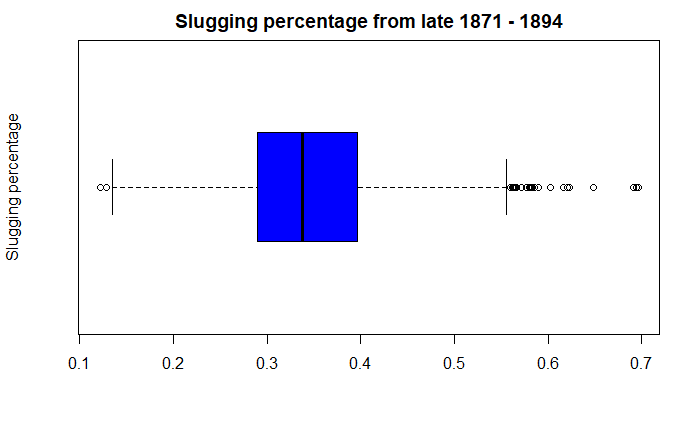

```r
boxplot(hitters1,
        main = "Slugging percentage from late 1871 - 1894",
        ylab = "Slugging percentage",
        col = "blue",
        horizontal = TRUE)
```

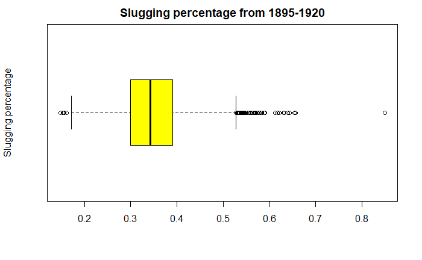

```r
boxplot(hitters2,
        main = "Slugging percentage from 1895-1920",
        ylab = "Slugging percentage",
        col = "yellow",
        horizontal = TRUE)
```

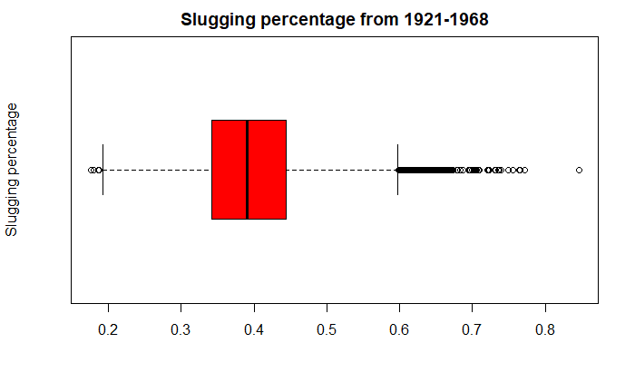

```r
boxplot(hitters3,
        main = "Slugging percentage from 1921-1968",
        ylab = "Slugging percentage",
        col = "red",
        horizontal = TRUE)
```

```r
boxplot(hitters4,
        main = "Slugging percentage from 1969 - present",
        ylab = "Slugging percentage",
        col = "green",
        horizontal = TRUE)
```

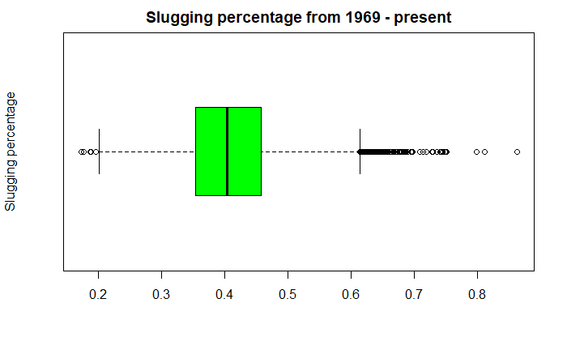

```r
sapply(hitters1, mean, na.rm = T)
```

```
  SlugPct
0.3456088
```

```r
sapply(hitters2, mean, na.rm = T)
```

```
 SlugPct
0.348923
```

```r
sapply(hitters3, mean, na.rm = T)
```

```
  SlugPct
0.3972127
```

```r
sapply(hitters4, mean, na.rm = T)
```

```
  SlugPct
0.4088045
```

```r
#Notice that gigantic increase between hitters2 and hitters3
```

```r
summary(hitters1)
```

```
    SlugPct
 Min.   :0.1220
 1st Qu.:0.2900
 Median :0.3380
 Mean   :0.3456
 3rd Qu.:0.3970
 Max.   :0.6960
```

```r
summary(hitters2)
```

```
    SlugPct
 Min.   :0.1480
 1st Qu.:0.3003
 Median :0.3430
 Mean   :0.3489
 3rd Qu.:0.3910
 Max.   :0.8490
```

```r
summary(hitters3)
```

```
    SlugPct
 Min.   :0.1760
 1st Qu.:0.3420
 Median :0.3900
 Mean   :0.3972
 3rd Qu.:0.4440
 Max.   :0.8460
```

```r
summary(hitters4)
```

```
    SlugPct
 Min.   :0.1730
 1st Qu.:0.3540
 Median :0.4040
 Mean   :0.4088
 3rd Qu.:0.4580
 Max.   :0.8630
```

```r
#Keep batting stats that we want for pairs.
batting_num <- bstats %>%
  filter(PA >= 150) %>%
  select("BA", 'OBP', 'SlugPct', "SO", "BB", "HR")
```

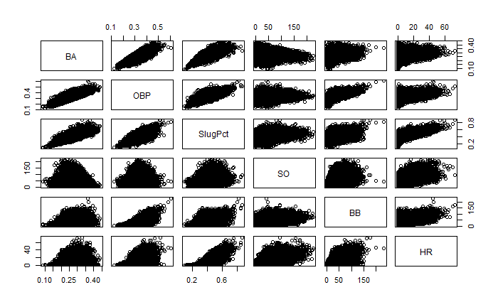

```r
pairs(batting_num)
```

#### Career Batting Stats

```r
careerBatting <- na.omit(bstats)
```

```r
careerBatting <- careerBatting %>%
  select(playerID, BA, PA, SlugPct, OBP, SO, HR) %>%
  group_by(playerID) %>%
  summarise_all('mean')
```

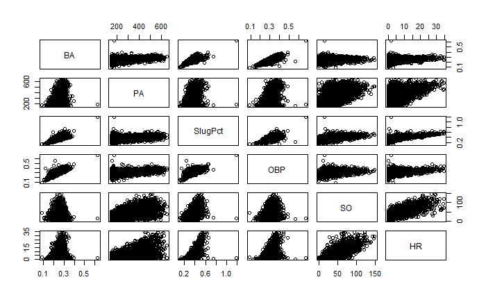

```r
careerBatting_num <- careerBatting %>%
  filter(PA >= 150) %>%
  select(BA, PA, SlugPct, OBP, SO, HR)

pairs(careerBatting_num)
```

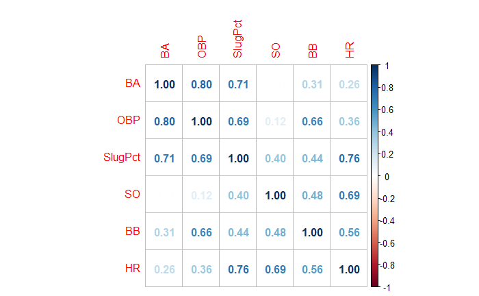

```r
corrmatrix <- cor(batting_num)
corrplot(corrmatrix, method = 'number') #Gives us correlation from pairs graph.
```

```r
careerBatting_num1 <- careerBatting_num %>%
  filter(PA > 500)
```

## PCA (Lesson 4)

```r
res <- batting_num %>% prcomp(scale = TRUE)
res
```

```
Standard deviations (1, .., p=6):
[1] 1.8624983 1.1955799 0.8163046 0.5272521 0.3234188
[6] 0.2296540

Rotation (n x k) = (6 x 6):
               PC1         PC2         PC3
BA      -0.3736490  0.53149382  0.20948811
OBP     -0.4412694  0.38795844 -0.30295510
SlugPct -0.4816546  0.08527252  0.45916589
SO      -0.2974863 -0.61917967  0.04176753
BB      -0.4043725 -0.14520286 -0.75150469
HR      -0.4262175 -0.39403532  0.29495049
                PC4        PC5          PC6
BA      -0.39409469  0.6134310  0.049063667
OBP     -0.06651166 -0.5817204  0.469217735
SlugPct  0.20230952 -0.3441137 -0.624948649
SO      -0.71554909 -0.1194610  0.009617743
BB       0.19652707  0.2909420 -0.356888661
HR       0.49870136  0.2607132  0.509317820
```

```r
loadings <- res$rotation
loadings
```

```
               PC1         PC2         PC3
BA      -0.3736490  0.53149382  0.20948811
OBP     -0.4412694  0.38795844 -0.30295510
SlugPct -0.4816546  0.08527252  0.45916589
SO      -0.2974863 -0.61917967  0.04176753
BB      -0.4043725 -0.14520286 -0.75150469
HR      -0.4262175 -0.39403532  0.29495049
                PC4        PC5          PC6
BA      -0.39409469  0.6134310  0.049063667
OBP     -0.06651166 -0.5817204  0.469217735
SlugPct  0.20230952 -0.3441137 -0.624948649
SO      -0.71554909 -0.1194610  0.009617743
BB       0.19652707  0.2909420 -0.356888661
HR       0.49870136  0.2607132  0.509317820
```

```r
score_mat <- res$x
score_mat
```

```
                   PC1           PC2           PC3
    [1,] -2.416723e+00  4.560698e+00  1.443027e+00
    [2,]  1.219725e+00  1.849015e+00  8.201252e-01
    [3,]  1.474218e+00  7.482123e-01  9.141729e-01
    [4,]  6.203888e-01  2.304795e+00  1.057469e+00
    [5,]  2.943669e+00  3.660013e-01  5.506029e-01
    [6,]  1.777087e+00  1.308355e+00  8.996221e-01
    [7,]  1.638294e+00  1.365860e+00  9.687942e-01
    [8,]  1.277859e+00  1.429171e+00  1.237701e+00
    [9,]  2.575716e+00  7.738965e-01  5.169331e-01
   [10,]  1.406601e+00  1.626801e+00  1.019207e+00
   [11,]  2.314598e+00  1.032260e+00  3.284764e-01
   [12,] -2.254698e+00  4.915125e+00  1.951355e+00
   [13,]  1.714346e+00  1.191014e+00  1.054853e+00
   [14,]  4.214521e+00 -5.515752e-01  3.050290e-01
```

[output cut: 320 more lines]

```r
get_eig(res)
```

|  | eigenvalue | variance.percent | cumulative.variance.percent |
| --- | --- | --- | --- |
| Dim.1 | 3.46889993 | 57.8149988 | 57.81500 |
| Dim.2 | 1.42941135 | 23.8235226 | 81.63852 |
| Dim.3 | 0.66635325 | 11.1058875 | 92.74441 |
| Dim.4 | 0.27799477 | 4.6332461 | 97.37766 |
| Dim.5 | 0.10459973 | 1.7433289 | 99.12098 |
| Dim.6 | 0.05274097 | 0.8790161 | 100.00000 |

#### Screeplot

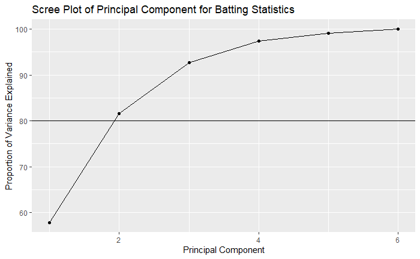

```r
get_eig(res) %>%
  ggplot(aes(x = 1:6, y = cumulative.variance.percent)) +
  geom_line() +
  geom_point() +
  geom_hline(yintercept = 80) +
  xlab("Principal Component") +
  ylab("Proportion of Variance Explained") +
  ggtitle("Scree Plot of Principal Component for Batting Statistics")
```

2 Principal Components: PC1 and PC2

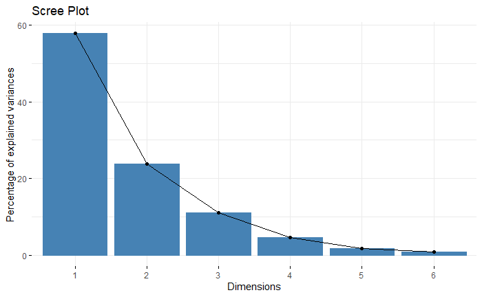

```r
fviz_screeplot(res, main = "Scree Plot")
```

Can Identify an elbow in 3.

#### Biplot

```r
res %>%
  fviz_pca_var(axes = c(1,2),
               col.var = "contrib",
               gradient.cols = c("#00AFBB", "#E7B800", "#FC4E07"),
               repel = TRUE
               )
```

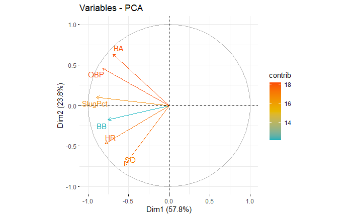

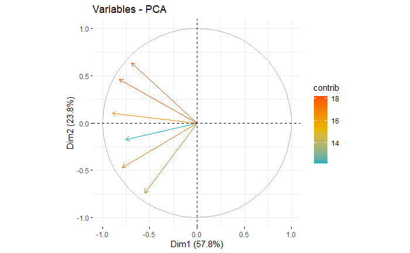

## Cluster Analysis (Lesson 5)

```r
careerBatting100 <- careerBatting %>%
  filter(PA >= 100)
```

```r
careerBatting100sample <-
  sample(careerBatting100,50)
```

[output not shown]

```r
plot(dend, labels = career_hc$playerID)
```

[output not shown]

```r
careerdend <- dist(careerBatting100sample, method = "euclidean", upper = TRUE)
```

```
NAs introduced by coercion
```

```r
careerdend <- get_dist(careerBatting100sample, method = "euclidean")
```

```
NAs introduced by coercion
```

```r
career_sing <- hclust(careerdend, method = "single")
career_complete<- hclust(careerdend, method = 'complete')
career_average <- hclust(careerdend, method = "average")
career_centroid <- hclust(careerdend, method = "centroid")
```

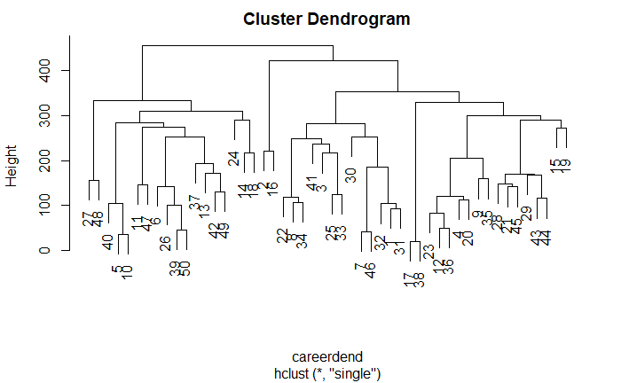

```r
plot(career_sing)
```

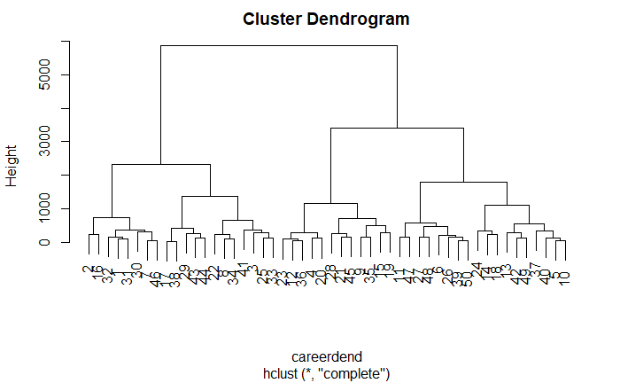

```r
plot(career_complete)
```

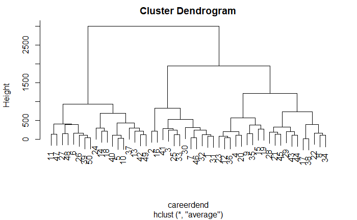

```r
plot(career_average)
```

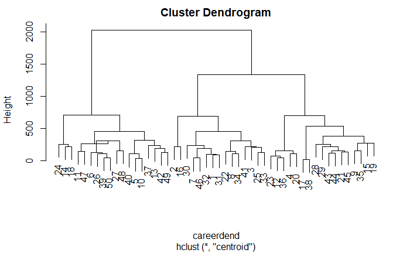

```r
plot(career_centroid)
```

```r
fviz(career_centroid, k = 2, k_colors = "jco", as.ggplot = TRUE, show_labels = TRUE, main = "Euclidean-Centroid")
```

[output not shown]

```r
#NOT COMPLETE!!!!! This was just a test, bstats is way too big.
bstats_best <- bstats %>%
  filter(PA >= 600)

eu_dist <- get_dist(careerBatting_num1, method = 'euclidean')
```

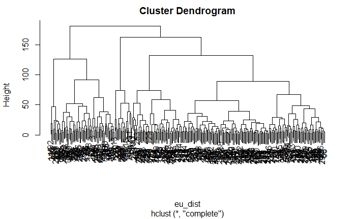

```r
hc_complete <- hclust(eu_dist, method = 'complete')
plot(hc_complete)
```

#### Silhouette

```r
res_test <- careerBatting_num1 %>% kmeans(7)
  str(res_test)
```

[output not shown]

[output cut: 132 more lines]

[output not shown]

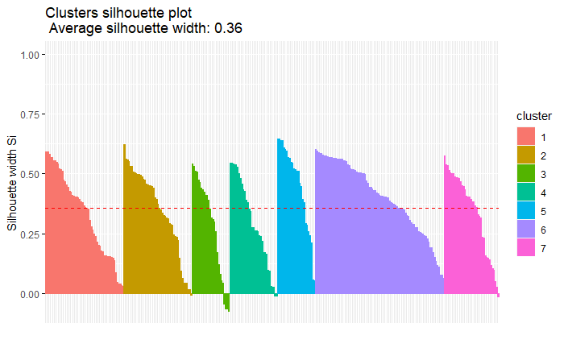

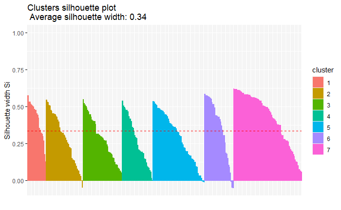

[figure not shown]

[figure not shown]

## Linear Regression (Lesson 6)

Linear Regression comparing team payroll and win rate.

```r
teams = as.data.table(Teams)
teams = teams[, .(yearID,
                  lgID = as.character(lgID),
                  teamID = as.character(teamID),
                  franchID = as.character(franchID),
                  Rank, G, W, L, R, ERA, SO,
                  WinPercent = W/(W+L))]

salaries = as.data.table(Salaries)
salaries = salaries[, c("lgID", "teamID", "salary1M") :=
                      list(as.character(lgID), as.character(teamID), salary / 1e6L)]
payroll = salaries[, .(payroll = sum(salary1M)), by=.(teamID, yearID)]
teamPayroll = merge(teams, payroll, by = c("teamID", "yearID"))
```

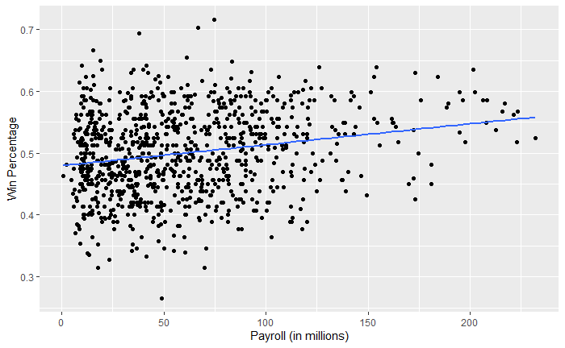

```r
ggplot(data = teamPayroll, aes(x = payroll, y = WinPercent)) + geom_point()  + labs(x = "Payroll (in millions)", y = "Win Percentage") +
  geom_smooth(method = lm, se = FALSE)
```

```r
mod_lm <- lm(data = teamPayroll, WinPercent~payroll)
mod_lm
```

```
Call:
lm(formula = WinPercent ~ payroll, data = teamPayroll)

Coefficients:
(Intercept)      payroll
  0.4796007    0.0003396
```

```r
summary(mod_lm)
```

```
Call:
lm(formula = WinPercent ~ payroll, data = teamPayroll)

Residuals:
      Min        1Q    Median        3Q       Max
-0.230866 -0.048237 -0.000954  0.049584  0.211074

Coefficients:
             Estimate Std. Error t value Pr(>|t|)
(Intercept) 0.4796007  0.0037895 126.561  < 2e-16 ***
payroll     0.0003396  0.0000512   6.633 5.61e-11 ***
---
Signif. codes:
0 ‘***’ 0.001 ‘**’ 0.01 ‘*’ 0.05 ‘.’ 0.1 ‘ ’ 1

Residual standard error: 0.06714 on 916 degrees of freedom
Multiple R-squared:  0.04583,   Adjusted R-squared:  0.04479
F-statistic:    44 on 1 and 916 DF,  p-value: 5.611e-11
```

```r
payroll_pred <- teamPayroll %>%
  add_predictions(mod_lm)

payroll_pred %>%
  filter(yearID >= 2010) %>%
  arrange(desc(pred)) %>%
  head(25)
```

| teamID | yearID | lgID | franchID | Rank | G | W | L | R | ERA | SO | WinPercent | payroll | pred |
| --- | --- | --- | --- | --- | --- | --- | --- | --- | --- | --- | --- | --- | --- |
| NYA | 2013 | AL | NYY | 4 | 162 | 85 | 77 | 650 | 3.94 | 1214 | 0.5246914 | 231.9789 | 0.5583788 |
| LAN | 2013 | NL | LAD | 1 | 162 | 92 | 70 | 649 | 3.25 | 1146 | 0.5679012 | 223.3622 | 0.5554527 |
| NYA | 2016 | AL | NYY | 4 | 162 | 84 | 78 | 680 | 4.16 | 1188 | 0.5185185 | 222.9978 | 0.5553289 |
| LAN | 2016 | NL | LAD | 1 | 162 | 91 | 71 | 725 | 3.70 | 1321 | 0.5617284 | 221.2884 | 0.5547484 |
| LAN | 2014 | NL | LAD | 1 | 162 | 94 | 68 | 718 | 3.40 | 1246 | 0.5802469 | 217.0146 | 0.5532971 |
| LAN | 2015 | NL | LAD | 1 | 162 | 92 | 70 | 667 | 3.44 | 1258 | 0.5679012 | 215.7920 | 0.5528819 |
| NYA | 2015 | AL | NYY | 2 | 162 | 87 | 75 | 764 | 4.03 | 1227 | 0.5370370 | 212.7520 | 0.5518495 |
| NYA | 2010 | AL | NYY | 2 | 162 | 95 | 67 | 859 | 4.06 | 1136 | 0.5864198 | 206.3334 | 0.5496698 |
| NYA | 2011 | AL | NYY | 1 | 162 | 97 | 65 | 867 | 3.73 | 1138 | 0.5987654 | 202.2750 | 0.5482916 |
| NYA | 2014 | AL | NYY | 2 | 162 | 84 | 78 | 633 | 3.75 | 1133 | 0.5185185 | 197.5439 | 0.5466850 |

[output cut: 15 more lines]

```r
payroll_pred %>%
  filter(yearID >= 2010) %>%
  arrange(desc(WinPercent)) %>%
  head(25)
```

| teamID | yearID | lgID | franchID | Rank | G | W | L | R | ERA | SO | WinPercent | payroll | pred |
| --- | --- | --- | --- | --- | --- | --- | --- | --- | --- | --- | --- | --- | --- |
| CHN | 2016 | NL | CHC | 1 | 162 | 103 | 58 | 808 | 3.15 | 1339 | 0.6397516 | 154.06767 | 0.5319208 |
| PHI | 2011 | NL | PHI | 1 | 162 | 102 | 60 | 713 | 3.02 | 1024 | 0.6296296 | 172.97638 | 0.5383420 |
| SLN | 2015 | NL | STL | 1 | 162 | 100 | 62 | 647 | 2.94 | 1267 | 0.6172840 | 119.24150 | 0.5200941 |
| LAA | 2014 | AL | ANA | 1 | 162 | 98 | 64 | 773 | 3.58 | 1266 | 0.6049383 | 121.98825 | 0.5210269 |
| PIT | 2015 | NL | PIT | 2 | 162 | 98 | 64 | 697 | 3.21 | 1322 | 0.6049383 | 88.89250 | 0.5097878 |
| WAS | 2012 | NL | WSN | 1 | 162 | 98 | 64 | 731 | 3.33 | 1325 | 0.6049383 | 80.85514 | 0.5070584 |
| BOS | 2013 | AL | BOS | 1 | 162 | 97 | 65 | 853 | 3.79 | 1308 | 0.5987654 | 151.53000 | 0.5310590 |
| CHN | 2015 | NL | CHC | 3 | 162 | 97 | 65 | 689 | 3.36 | 1518 | 0.5987654 | 115.87931 | 0.5189523 |
| CIN | 2012 | NL | CIN | 1 | 162 | 97 | 65 | 669 | 3.34 | 1266 | 0.5987654 | 82.20362 | 0.5075163 |
| NYA | 2011 | AL | NYY | 1 | 162 | 97 | 65 | 867 | 3.73 | 1138 | 0.5987654 | 202.27503 | 0.5482916 |

[output cut: 15 more lines]

## Multiple Linear Regression

```r
bstats_salary <- bstats_salary %>%
  filter(PA >= 100) %>%
  filter(salary > 500000)
```

```r
bstats_salary_21century <- bstats_salary %>%
  filter(yearID >= 2002)
```

```r
lm_mod <- lm(salary ~ H, HR, data = bstats_salary_21century)
summary(lm_mod)
```

```
Call:
lm(formula = salary ~ H, data = bstats_salary_21century, subset = HR)

Residuals:
     Min       1Q   Median       3Q      Max
-4454703 -1184411  -175489   774007 14030406

Coefficients:
             Estimate Std. Error t value Pr(>|t|)
(Intercept) -175015.7    82216.4  -2.129   0.0333 *
H             39604.4      661.7  59.854   <2e-16 ***
---
Signif. codes:
0 ‘***’ 0.001 ‘**’ 0.01 ‘*’ 0.05 ‘.’ 0.1 ‘ ’ 1

Residual standard error: 2299000 on 3982 degrees of freedom
Multiple R-squared:  0.4736,    Adjusted R-squared:  0.4735
F-statistic:  3583 on 1 and 3982 DF,  p-value: < 2.2e-16
```

```r
lm_mod_prd <- bstats_salary_21century %>% add_predictions(lm_mod)
lm_mod_prd
```

| playerID | yearID | stint | teamID | lgID | G | AB | R | H | X2B | X3B | HR | RBI | SB | CS | BB | SO | IBB | HBP | SH | SF | GIDP | BA | PA | TB | SlugPct | OBP | OPS | BABIP | K_Percent | … |
| --- | --- | --- | --- | --- | --- | --- | --- | --- | --- | --- | --- | --- | --- | --- | --- | --- | --- | --- | --- | --- | --- | --- | --- | --- | --- | --- | --- | --- | --- | --- |
| abreubo01 | 2002 | 1 | PHI | NL | 157 | 572 | 102 | 176 | 50 | 6 | 20 | 85 | 31 | 12 | 104 | 117 | 9 | 3 | 0 | 6 | 11 | 0.308 | 685 | 298 | 0.521 | 0.413 | 0.934 | 0.354 | 0.171 | … |
| agbaybe01 | 2002 | 1 | COL | NL | 48 | 117 | 10 | 24 | 5 | 0 | 4 | 19 | 1 | 0 | 10 | 35 | 0 | 0 | 0 | 1 | 4 | 0.205 | 128 | 41 | 0.350 | 0.266 | 0.616 | 0.253 | 0.273 | … |
| alfoned01 | 2002 | 1 | NYN | NL | 135 | 490 | 78 | 151 | 26 | 0 | 16 | 56 | 6 | 0 | 62 | 55 | 8 | 7 | 0 | 3 | 5 | 0.308 | 562 | 225 | 0.459 | 0.391 | 0.850 | 0.320 | 0.098 | … |
| alicelu01 | 2002 | 1 | KCA | AL | 94 | 237 | 28 | 54 | 8 | 2 | 1 | 23 | 2 | 3 | 32 | 34 | 1 | 1 | 3 | 0 | 5 | 0.228 | 273 | 69 | 0.291 | 0.322 | 0.613 | 0.262 | 0.125 | … |
| alomaro01 | 2002 | 1 | NYN | NL | 149 | 590 | 73 | 157 | 24 | 4 | 11 | 53 | 16 | 4 | 57 | 83 | 4 | 1 | 6 | 1 | 12 | 0.266 | 655 | 222 | 0.376 | 0.331 | 0.707 | 0.294 | 0.127 | … |
| alomasa02 | 2002 | 1 | CHA | AL | 51 | 167 | 21 | 48 | 10 | 1 | 7 | 25 | 0 | 0 | 5 | 14 | 0 | 1 | 1 | 2 | 5 | 0.287 | 176 | 81 | 0.485 | 0.309 | 0.794 | 0.277 | 0.080 | … |
| aloumo01 | 2002 | 1 | CHN | NL | 132 | 484 | 50 | 133 | 23 | 1 | 15 | 61 | 8 | 0 | 47 | 61 | 4 | 0 | 0 | 3 | 15 | 0.275 | 534 | 203 | 0.419 | 0.337 | 0.756 | 0.287 | 0.114 | … |
| anderga01 | 2002 | 1 | ANA | AL | 158 | 638 | 93 | 195 | 56 | 3 | 29 | 123 | 6 | 4 | 30 | 80 | 11 | 0 | 0 | 10 | 11 | 0.306 | 678 | 344 | 0.539 | 0.332 | 0.871 | 0.308 | 0.118 | … |
| aurilri01 | 2002 | 1 | SFN | NL | 133 | 538 | 76 | 138 | 35 | 2 | 15 | 61 | 1 | 2 | 37 | 90 | 0 | 4 | 3 | 7 | 15 | 0.257 | 589 | 222 | 0.413 | 0.305 | 0.718 | 0.280 | 0.153 | … |
| ausmubr01 | 2002 | 1 | HOU | NL | 130 | 447 | 57 | 115 | 19 | 3 | 6 | 50 | 2 | 3 | 38 | 71 | 3 | 6 | 2 | 3 | 30 | 0.257 | 496 | 158 | 0.353 | 0.322 | 0.675 | 0.292 | 0.143 | … |

[output cut: 990 more lines]

```r
full_model <- lm(salary ~., data = bstats_salary_21century)
summary(full_model)
```

```
Call:
lm(formula = salary ~ ., data = bstats_salary_21century)

Residuals:
      Min        1Q    Median        3Q       Max
-15323368  -1127665         0   1254066  12871792

Coefficients: (3 not defined because of singularities)
                    Estimate Std. Error t value
(Intercept)       -1.286e+09  5.422e+07 -23.712
playerIDabreujo02 -7.317e+06  2.046e+06  -3.576
playerIDackledu01 -1.297e+07  1.806e+06  -7.180
playerIDadamecr01 -1.070e+07  3.117e+06  -3.432
playerIDadamsda02 -1.347e+07  3.085e+06  -4.365
playerIDadamsma01 -1.383e+07  1.996e+06  -6.927
playerIDadducji02 -1.145e+07  3.093e+06  -3.700
playerIDadriaeh01 -1.127e+07  3.099e+06  -3.637
playerIDagbaybe01 -4.126e+06  3.115e+06  -1.325
playerIDahmedni01 -1.344e+07  2.334e+06  -5.756
playerIDalfoned01 -3.760e+06  1.812e+06  -2.075
playerIDalicelu01 -4.490e+06  3.108e+06  -1.445
playerIDalomaro01 -2.833e+06  1.983e+06  -1.429
playerIDalomasa02 -5.953e+06  1.834e+06  -3.245
playerIDalonsyo01 -1.311e+07  1.672e+06  -7.839
playerIDaloumo01  -2.724e+06  1.589e+06  -1.715
playerIDaltheaa01 -1.513e+07  3.080e+06  -4.913
playerIDaltuvjo01 -1.197e+07  2.039e+06  -5.873
playerIDalvarpe01 -1.057e+07  1.612e+06  -6.560
playerIDamarial01 -1.192e+07  2.333e+06  -5.109
playerIDamezaal01 -5.945e+06  3.118e+06  -1.907
playerIDanderga01 -4.053e+06  1.445e+06  -2.805
playerIDanderma02 -5.572e+06  1.793e+06  -3.108
playerIDandinro01 -1.112e+07  3.099e+06  -3.588
playerIDandruel01 -4.611e+06  1.710e+06  -2.696
playerIDankieri01 -9.386e+06  1.668e+06  -5.627
playerIDaokino01  -1.109e+07  1.696e+06  -6.539
playerIDarciaos01 -1.335e+07  2.354e+06  -5.669
playerIDarenano01 -1.197e+07  2.365e+06  -5.062
playerIDarencjp01 -1.314e+07  2.327e+06  -5.647
playerIDariasjo01 -9.841e+06  2.351e+06  -4.187
```

[output cut: 363 more lines]

```
playerIDcorpoca01 3.80e-09 ***
playerIDcorreca01 2.48e-07 ***
playerIDcounscr01 3.19e-05 ***
playerIDcowgico01 7.26e-06 ***
playerIDcozarza01 3.13e-11 ***
playerIDcraigal01 4.22e-07 ***
playerIDcrawfbr01 5.04e-12 ***
 [ reached getOption("max.print") -- omitted 858 rows ]
---
Signif. codes:
0 ‘***’ 0.001 ‘**’ 0.01 ‘*’ 0.05 ‘.’ 0.1 ‘ ’ 1

Residual standard error: 2889000 on 3072 degrees of freedom
Multiple R-squared:  0.7694,    Adjusted R-squared:  0.6903
F-statistic: 9.724 on 1054 and 3072 DF,  p-value: < 2.2e-16
```

```r
full_model_pred <- bstats_salary_21century %>% add_predictions(full_model)
```

```
prediction from a rank-deficient fit may be misleading
```

```r
full_model_pred
```

| playerID | yearID | stint | teamID | lgID | G | AB | R | H | X2B | X3B | HR | RBI | SB | CS | BB | SO | IBB | HBP | SH | SF | GIDP | BA | PA | TB | SlugPct | OBP | OPS | BABIP | K_Percent | … |
| --- | --- | --- | --- | --- | --- | --- | --- | --- | --- | --- | --- | --- | --- | --- | --- | --- | --- | --- | --- | --- | --- | --- | --- | --- | --- | --- | --- | --- | --- | --- |
| abreubo01 | 2002 | 1 | PHI | NL | 157 | 572 | 102 | 176 | 50 | 6 | 20 | 85 | 31 | 12 | 104 | 117 | 9 | 3 | 0 | 6 | 11 | 0.308 | 685 | 298 | 0.521 | 0.413 | 0.934 | 0.354 | 0.171 | … |
| agbaybe01 | 2002 | 1 | COL | NL | 48 | 117 | 10 | 24 | 5 | 0 | 4 | 19 | 1 | 0 | 10 | 35 | 0 | 0 | 0 | 1 | 4 | 0.205 | 128 | 41 | 0.350 | 0.266 | 0.616 | 0.253 | 0.273 | … |
| alfoned01 | 2002 | 1 | NYN | NL | 135 | 490 | 78 | 151 | 26 | 0 | 16 | 56 | 6 | 0 | 62 | 55 | 8 | 7 | 0 | 3 | 5 | 0.308 | 562 | 225 | 0.459 | 0.391 | 0.850 | 0.320 | 0.098 | … |
| alicelu01 | 2002 | 1 | KCA | AL | 94 | 237 | 28 | 54 | 8 | 2 | 1 | 23 | 2 | 3 | 32 | 34 | 1 | 1 | 3 | 0 | 5 | 0.228 | 273 | 69 | 0.291 | 0.322 | 0.613 | 0.262 | 0.125 | … |
| alomaro01 | 2002 | 1 | NYN | NL | 149 | 590 | 73 | 157 | 24 | 4 | 11 | 53 | 16 | 4 | 57 | 83 | 4 | 1 | 6 | 1 | 12 | 0.266 | 655 | 222 | 0.376 | 0.331 | 0.707 | 0.294 | 0.127 | … |
| alomasa02 | 2002 | 1 | CHA | AL | 51 | 167 | 21 | 48 | 10 | 1 | 7 | 25 | 0 | 0 | 5 | 14 | 0 | 1 | 1 | 2 | 5 | 0.287 | 176 | 81 | 0.485 | 0.309 | 0.794 | 0.277 | 0.080 | … |
| aloumo01 | 2002 | 1 | CHN | NL | 132 | 484 | 50 | 133 | 23 | 1 | 15 | 61 | 8 | 0 | 47 | 61 | 4 | 0 | 0 | 3 | 15 | 0.275 | 534 | 203 | 0.419 | 0.337 | 0.756 | 0.287 | 0.114 | … |
| anderga01 | 2002 | 1 | ANA | AL | 158 | 638 | 93 | 195 | 56 | 3 | 29 | 123 | 6 | 4 | 30 | 80 | 11 | 0 | 0 | 10 | 11 | 0.306 | 678 | 344 | 0.539 | 0.332 | 0.871 | 0.308 | 0.118 | … |
| aurilri01 | 2002 | 1 | SFN | NL | 133 | 538 | 76 | 138 | 35 | 2 | 15 | 61 | 1 | 2 | 37 | 90 | 0 | 4 | 3 | 7 | 15 | 0.257 | 589 | 222 | 0.413 | 0.305 | 0.718 | 0.280 | 0.153 | … |
| ausmubr01 | 2002 | 1 | HOU | NL | 130 | 447 | 57 | 115 | 19 | 3 | 6 | 50 | 2 | 3 | 38 | 71 | 3 | 6 | 2 | 3 | 30 | 0.257 | 496 | 158 | 0.353 | 0.322 | 0.675 | 0.292 | 0.143 | … |

[output cut: 990 more lines]

```r
adv_stat_mod <- lm(salary ~ OPS, data = bstats_salary_21century)
summary(adv_stat_mod)
```

```
Call:
lm(formula = salary ~ OPS, data = bstats_salary_21century)

Residuals:
      Min        1Q    Median        3Q       Max
-10237320  -3222583  -1313128   1912953  26166519

Coefficients:
            Estimate Std. Error t value Pr(>|t|)
(Intercept) -7241235     498661  -14.52   <2e-16 ***
OPS         16617138     664556   25.00   <2e-16 ***
---
Signif. codes:
0 ‘***’ 0.001 ‘**’ 0.01 ‘*’ 0.05 ‘.’ 0.1 ‘ ’ 1

Residual standard error: 4837000 on 4125 degrees of freedom
Multiple R-squared:  0.1316,    Adjusted R-squared:  0.1314
F-statistic: 625.2 on 1 and 4125 DF,  p-value: < 2.2e-16
```

## Resampling Methods

```r
#including 2002 and up because salary becomes higher
bstats_salary_21century <- bstats_salary %>%
  filter(yearID >= 2002)
```

```r
bstats_salary_21century %>% head(10)
```

|  | playerID | yearID | stint | teamID | lgID | G | AB | R | H | X2B | X3B | HR | RBI | SB | CS | BB | SO | IBB | HBP | SH | SF | GIDP | BA | PA | TB | SlugPct | OBP | OPS | BABIP | … |
| --- | --- | --- | --- | --- | --- | --- | --- | --- | --- | --- | --- | --- | --- | --- | --- | --- | --- | --- | --- | --- | --- | --- | --- | --- | --- | --- | --- | --- | --- | --- |
| 1 | abreubo01 | 2002 | 1 | PHI | NL | 157 | 572 | 102 | 176 | 50 | 6 | 20 | 85 | 31 | 12 | 104 | 117 | 9 | 3 | 0 | 6 | 11 | 0.308 | 685 | 298 | 0.521 | 0.413 | 0.934 | 0.354 | … |
| 2 | agbaybe01 | 2002 | 1 | COL | NL | 48 | 117 | 10 | 24 | 5 | 0 | 4 | 19 | 1 | 0 | 10 | 35 | 0 | 0 | 0 | 1 | 4 | 0.205 | 128 | 41 | 0.350 | 0.266 | 0.616 | 0.253 | … |
| 3 | alfoned01 | 2002 | 1 | NYN | NL | 135 | 490 | 78 | 151 | 26 | 0 | 16 | 56 | 6 | 0 | 62 | 55 | 8 | 7 | 0 | 3 | 5 | 0.308 | 562 | 225 | 0.459 | 0.391 | 0.850 | 0.320 | … |
| 4 | alicelu01 | 2002 | 1 | KCA | AL | 94 | 237 | 28 | 54 | 8 | 2 | 1 | 23 | 2 | 3 | 32 | 34 | 1 | 1 | 3 | 0 | 5 | 0.228 | 273 | 69 | 0.291 | 0.322 | 0.613 | 0.262 | … |
| 5 | alomaro01 | 2002 | 1 | NYN | NL | 149 | 590 | 73 | 157 | 24 | 4 | 11 | 53 | 16 | 4 | 57 | 83 | 4 | 1 | 6 | 1 | 12 | 0.266 | 655 | 222 | 0.376 | 0.331 | 0.707 | 0.294 | … |
| 6 | alomasa02 | 2002 | 1 | CHA | AL | 51 | 167 | 21 | 48 | 10 | 1 | 7 | 25 | 0 | 0 | 5 | 14 | 0 | 1 | 1 | 2 | 5 | 0.287 | 176 | 81 | 0.485 | 0.309 | 0.794 | 0.277 | … |
| 7 | aloumo01 | 2002 | 1 | CHN | NL | 132 | 484 | 50 | 133 | 23 | 1 | 15 | 61 | 8 | 0 | 47 | 61 | 4 | 0 | 0 | 3 | 15 | 0.275 | 534 | 203 | 0.419 | 0.337 | 0.756 | 0.287 | … |
| 8 | anderga01 | 2002 | 1 | ANA | AL | 158 | 638 | 93 | 195 | 56 | 3 | 29 | 123 | 6 | 4 | 30 | 80 | 11 | 0 | 0 | 10 | 11 | 0.306 | 678 | 344 | 0.539 | 0.332 | 0.871 | 0.308 | … |
| 9 | aurilri01 | 2002 | 1 | SFN | NL | 133 | 538 | 76 | 138 | 35 | 2 | 15 | 61 | 1 | 2 | 37 | 90 | 0 | 4 | 3 | 7 | 15 | 0.257 | 589 | 222 | 0.413 | 0.305 | 0.718 | 0.280 | … |
| 10 | ausmubr01 | 2002 | 1 | HOU | NL | 130 | 447 | 57 | 115 | 19 | 3 | 6 | 50 | 2 | 3 | 38 | 71 | 3 | 6 | 2 | 3 | 30 | 0.257 | 496 | 158 | 0.353 | 0.322 | 0.675 | 0.292 | … |

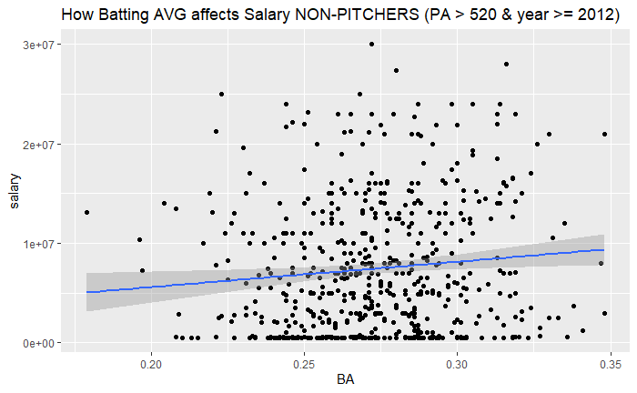

```r
# Salary of hitters with best batting avg
top_battingAVG <- bstats_salary_21century%>%
  filter(PA >= 520, yearID >= 2012) %>%
  select(BA, salary) %>%
  arrange(desc(BA))%>%
  head(1500)

  ggplot(data = top_battingAVG, aes(x = BA, y= salary)) +
    geom_point()+
    geom_smooth(method = lm) +
    labs(title="How Batting AVG affects Salary NON-PITCHERS (PA > 520 & year >= 2012)")
```

```r
bstats_salary_21century %>%
  arrange(desc(yearID))
```

| playerID | yearID | stint | teamID | lgID | G | AB | R | H | X2B | X3B | HR | RBI | SB | CS | BB | SO | IBB | HBP | SH | SF | GIDP | BA | PA | TB | SlugPct | OBP | OPS | BABIP | K_Percent | … |
| --- | --- | --- | --- | --- | --- | --- | --- | --- | --- | --- | --- | --- | --- | --- | --- | --- | --- | --- | --- | --- | --- | --- | --- | --- | --- | --- | --- | --- | --- | --- |
| abreujo02 | 2016 | 1 | CHA | AL | 159 | 624 | 67 | 183 | 32 | 1 | 25 | 100 | 0 | 2 | 47 | 125 | 7 | 15 | 0 | 9 | 21 | 0.293 | 695 | 292 | 0.468 | 0.353 | 0.821 | 0.327 | 0.180 | … |
| adamecr01 | 2016 | 1 | COL | NL | 121 | 225 | 25 | 49 | 7 | 3 | 2 | 17 | 2 | 3 | 24 | 47 | 0 | 4 | 3 | 0 | 5 | 0.218 | 256 | 68 | 0.302 | 0.304 | 0.606 | 0.267 | 0.184 | … |
| adamsma01 | 2016 | 1 | SLN | NL | 118 | 297 | 37 | 74 | 18 | 0 | 16 | 54 | 0 | 1 | 25 | 81 | 1 | 2 | 0 | 3 | 5 | 0.249 | 327 | 140 | 0.471 | 0.309 | 0.780 | 0.286 | 0.248 | … |
| ahmedni01 | 2016 | 1 | ARI | NL | 90 | 284 | 26 | 62 | 9 | 1 | 4 | 20 | 5 | 2 | 15 | 58 | 3 | 4 | 2 | 3 | 9 | 0.218 | 308 | 85 | 0.299 | 0.265 | 0.564 | 0.258 | 0.188 | … |
| alonsyo01 | 2016 | 1 | OAK | AL | 156 | 482 | 52 | 122 | 34 | 0 | 7 | 56 | 3 | 1 | 45 | 74 | 1 | 1 | 0 | 4 | 15 | 0.253 | 532 | 177 | 0.367 | 0.316 | 0.683 | 0.284 | 0.139 | … |
| altheaa01 | 2016 | 1 | PHI | NL | 57 | 198 | 23 | 39 | 6 | 0 | 4 | 22 | 7 | 2 | 23 | 69 | 2 | 6 | 0 | 0 | 4 | 0.197 | 227 | 57 | 0.288 | 0.300 | 0.588 | 0.280 | 0.304 | … |
| altuvjo01 | 2016 | 1 | HOU | AL | 161 | 640 | 108 | 216 | 42 | 5 | 24 | 96 | 30 | 10 | 60 | 70 | 11 | 7 | 3 | 7 | 15 | 0.338 | 717 | 340 | 0.531 | 0.396 | 0.927 | 0.347 | 0.098 | … |
| alvarpe01 | 2016 | 1 | BAL | AL | 109 | 337 | 43 | 84 | 20 | 0 | 22 | 49 | 1 | 0 | 37 | 97 | 1 | 0 | 0 | 2 | 6 | 0.249 | 376 | 170 | 0.504 | 0.322 | 0.826 | 0.282 | 0.258 | … |
| andruel01 | 2016 | 1 | TEX | AL | 147 | 506 | 75 | 153 | 31 | 7 | 8 | 69 | 24 | 8 | 47 | 70 | 2 | 4 | 4 | 7 | 18 | 0.302 | 568 | 222 | 0.439 | 0.362 | 0.801 | 0.333 | 0.123 | … |
| aokino01 | 2016 | 1 | SEA | AL | 118 | 417 | 63 | 118 | 24 | 4 | 4 | 28 | 7 | 9 | 34 | 45 | 0 | 9 | 5 | 1 | 9 | 0.283 | 466 | 162 | 0.388 | 0.349 | 0.737 | 0.309 | 0.097 | … |

[output cut: 990 more lines]

```r
# setting seed to generate a reproducible random sampling
set.seed(123)

# defining training control as cross-validation and value of K equal to 10
train_control <- trainControl(method = "cv",
                              number = 10)

# training the model
model <- train(salary ~ OBP, data = bstats_salary_21century,
               method = "lm",
               trControl = train_control)

print(model)
```

```
Linear Regression

4127 samples
   1 predictor

No pre-processing
Resampling: Cross-Validated (10 fold)
Summary of sample sizes: 3712, 3714, 3713, 3715, 3715, 3715, ...
Resampling results:

  RMSE     Rsquared   MAE
  4903905  0.1069253  3691779

Tuning parameter 'intercept' was held constant at
 a value of TRUE
```

## Feature Selection

```r
bstats_salary_numvars <- bstats_salary_21century %>%
  select(c(6:32))
```

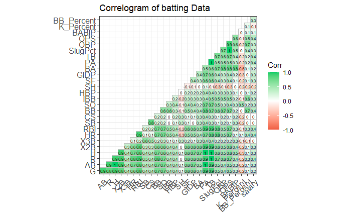

```r
#Correlation mapping

#making correlation heat map
corr_numeric <- round(cor(bstats_salary_numvars), 1)

#plot to visualize the correlations
ggcorrplot(corr_numeric,
           type = "lower",
           lab = TRUE,
           lab_size = 2,
           colors = c("tomato2", "white", "springgreen3"),
           title="Correlogram of batting Data",
           ggtheme=theme_bw)
```

```r
regfit.full = regsubsets(salary ~., data = bstats_salary_numvars,  nvmax = 13, method="exhaustive")
```

```
3  linear dependencies found
```

```
Reordering variables and trying again:
```

```r
summary(regfit.full)
```

```
Subset selection object
Call: regsubsets.formula(salary ~ ., data = bstats_salary_numvars,
    nvmax = 13, method = "exhaustive")
26 Variables  (and intercept)
           Forced in Forced out
G              FALSE      FALSE
AB             FALSE      FALSE
R              FALSE      FALSE
H              FALSE      FALSE
X2B            FALSE      FALSE
X3B            FALSE      FALSE
HR             FALSE      FALSE
RBI            FALSE      FALSE
SB             FALSE      FALSE
CS             FALSE      FALSE
BB             FALSE      FALSE
SO             FALSE      FALSE
IBB            FALSE      FALSE
HBP            FALSE      FALSE
SH             FALSE      FALSE
SF             FALSE      FALSE
GIDP           FALSE      FALSE
BA             FALSE      FALSE
SlugPct        FALSE      FALSE
OBP            FALSE      FALSE
BABIP          FALSE      FALSE
K_Percent      FALSE      FALSE
BB_Percent     FALSE      FALSE
PA             FALSE      FALSE
TB             FALSE      FALSE
OPS            FALSE      FALSE
1 subsets of each size up to 14
Selection Algorithm: exhaustive
          G   AB  R   H   X2B X3B HR  RBI SB  CS  BB
1  ( 1 )  " " " " " " " " " " " " " " "*" " " " " " "
2  ( 1 )  " " " " " " " " " " " " " " "*" " " " " " "
3  ( 1 )  "*" " " " " " " " " " " " " " " " " " " " "
4  ( 1 )  "*" " " " " " " " " " " " " " " " " " " " "
5  ( 1 )  "*" " " " " " " " " "*" " " " " " " " " " "
6  ( 1 )  "*" " " " " " " "*" "*" " " " " " " " " " "
```

[output cut: 23 more lines]

```
          SlugPct OBP OPS BABIP K_Percent BB_Percent
1  ( 1 )  " "     " " " " " "   " "       " "
2  ( 1 )  " "     " " " " " "   " "       "*"
3  ( 1 )  " "     " " " " " "   " "       " "
4  ( 1 )  " "     " " " " " "   " "       " "
5  ( 1 )  " "     " " " " " "   " "       " "
6  ( 1 )  " "     " " " " " "   " "       " "
7  ( 1 )  " "     " " "*" " "   " "       " "
8  ( 1 )  " "     " " "*" " "   " "       " "
9  ( 1 )  "*"     " " " " " "   " "       "*"
10  ( 1 ) "*"     " " " " " "   "*"       "*"
11  ( 1 ) "*"     " " " " " "   " "       "*"
12  ( 1 ) "*"     " " " " " "   "*"       "*"
13  ( 1 ) "*"     " " " " " "   " "       "*"
14  ( 1 ) " "     " " "*" "*"   " "       " "
```

```r
summary(regfit.full)$rsq
```

```
 [1] 0.1735921 0.1997069 0.2379362 0.2627538 0.2763364
 [6] 0.2820003 0.2891514 0.2937692 0.2962186 0.2979275
[11] 0.2997391 0.3013596 0.3020423 0.3031258
```

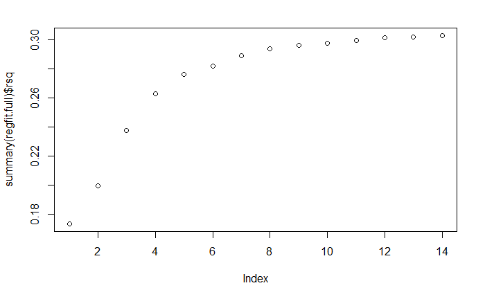

```r
plot(summary(regfit.full)$rsq)
```

```r
reg.summary <- summary(regfit.full) #get the summary

par(mfrow=c(2,2))
#rss plot -  NOT USEFUL
plot(reg.summary$rss ,xlab="Number of Variables ",ylab="RSS",type="l")

#adjr2 plot
plot(reg.summary$adjr2 ,xlab="Number of Variables ", ylab="Adjusted RSq",type="l")
```

```r
max_adjr2 <- which.max(reg.summary$adjr2)
points(max_adjr2,reg.summary$adjr2[max_adjr2], col="red",cex=2,pch=20)

# AIC criterion (Cp) to minimize
plot(reg.summary$cp ,xlab="Number of Variables ",ylab="Cp", type='l')
```

```r
min_cp <- which.min(reg.summary$cp )
points(min_cp, reg.summary$cp[min_cp],col="red",cex=2,pch=20)

# BIC criterion to minimize
plot(reg.summary$bic ,xlab="Number of Variables ",ylab="BIC",type='l')
```

```r
min_bic <- which.min(reg.summary$bic)
points(min_bic,reg.summary$bic[min_bic],col="red",cex=2,pch=20)
```

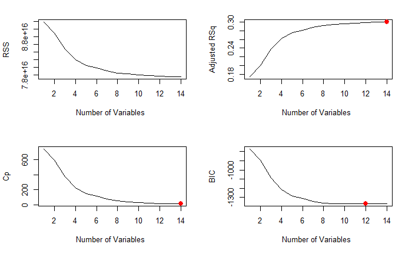

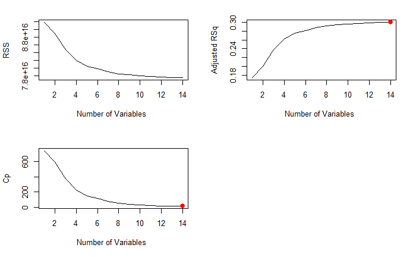

```r
#Forward stepwise selection
regfit.fwd = regsubsets(salary ~. , data=bstats_salary_numvars, nvmax=13, method ="forward")
```

```
3  linear dependencies found
```

```
Reordering variables and trying again:
```

```r
summary(regfit.fwd)
```

```
Subset selection object
Call: regsubsets.formula(salary ~ ., data = bstats_salary_numvars,
    nvmax = 13, method = "forward")
26 Variables  (and intercept)
           Forced in Forced out
G              FALSE      FALSE
AB             FALSE      FALSE
R              FALSE      FALSE
H              FALSE      FALSE
X2B            FALSE      FALSE
X3B            FALSE      FALSE
HR             FALSE      FALSE
RBI            FALSE      FALSE
SB             FALSE      FALSE
CS             FALSE      FALSE
BB             FALSE      FALSE
SO             FALSE      FALSE
IBB            FALSE      FALSE
HBP            FALSE      FALSE
SH             FALSE      FALSE
SF             FALSE      FALSE
GIDP           FALSE      FALSE
BA             FALSE      FALSE
SlugPct        FALSE      FALSE
OBP            FALSE      FALSE
BABIP          FALSE      FALSE
K_Percent      FALSE      FALSE
BB_Percent     FALSE      FALSE
PA             FALSE      FALSE
TB             FALSE      FALSE
OPS            FALSE      FALSE
1 subsets of each size up to 14
Selection Algorithm: forward
          G   AB  R   H   X2B X3B HR  RBI SB  CS  BB
1  ( 1 )  " " " " " " " " " " " " " " "*" " " " " " "
2  ( 1 )  " " " " " " " " " " " " " " "*" " " " " " "
3  ( 1 )  "*" " " " " " " " " " " " " "*" " " " " " "
4  ( 1 )  "*" "*" " " " " " " " " " " "*" " " " " " "
5  ( 1 )  "*" "*" " " " " " " "*" " " "*" " " " " " "
6  ( 1 )  "*" "*" " " " " " " "*" " " "*" " " " " " "
```

[output cut: 23 more lines]

```
          SlugPct OBP OPS BABIP K_Percent BB_Percent
1  ( 1 )  " "     " " " " " "   " "       " "
2  ( 1 )  " "     " " " " " "   " "       "*"
3  ( 1 )  " "     " " " " " "   " "       "*"
4  ( 1 )  " "     " " " " " "   " "       "*"
5  ( 1 )  " "     " " " " " "   " "       "*"
6  ( 1 )  " "     " " " " " "   " "       "*"
7  ( 1 )  " "     " " " " " "   " "       "*"
8  ( 1 )  " "     " " " " " "   " "       "*"
9  ( 1 )  " "     " " " " " "   " "       "*"
10  ( 1 ) " "     " " " " " "   "*"       "*"
11  ( 1 ) " "     " " " " " "   "*"       "*"
12  ( 1 ) " "     " " " " " "   "*"       "*"
13  ( 1 ) " "     " " " " " "   "*"       "*"
14  ( 1 ) " "     " " " " " "   "*"       "*"
```

```r
reg.summary <- summary(regfit.fwd) #get the summary

par(mfrow=c(2,2))
#rss plot -  NOT USEFUL
plot(reg.summary$rss ,xlab="Number of Variables ",ylab="RSS",type="l")

#adjr2 plot
plot(reg.summary$adjr2 ,xlab="Number of Variables ", ylab="Adjusted RSq",type="l")
```

```r
max_adjr2 <- which.max(reg.summary$adjr2)
points(max_adjr2,reg.summary$adjr2[max_adjr2], col="red",cex=2,pch=20)

# AIC criterion (Cp) to minimize
plot(reg.summary$cp ,xlab="Number of Variables ",ylab="Cp", type='l')
```

```r
min_cp <- which.min(reg.summary$cp )
points(min_cp, reg.summary$cp[min_cp],col="red",cex=2,pch=20)

# BIC criterion to minimize
plot(reg.summary$bic ,xlab="Number of Variables ",ylab="BIC",type='l')
```

```r
min_bic <- which.min(reg.summary$bic)
points(min_bic,reg.summary$bic[min_bic],col="red",cex=2,pch=20)
```

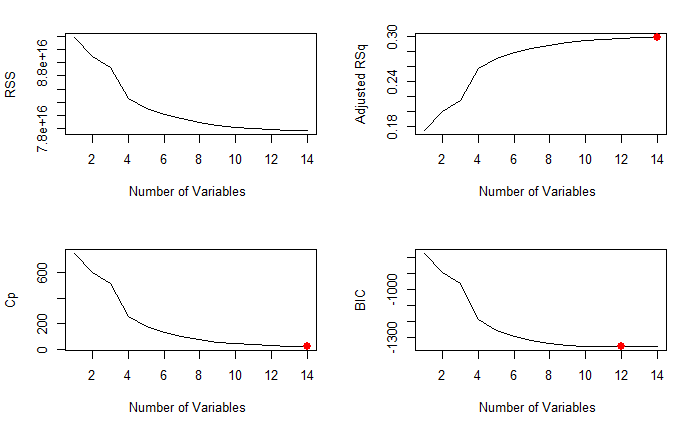

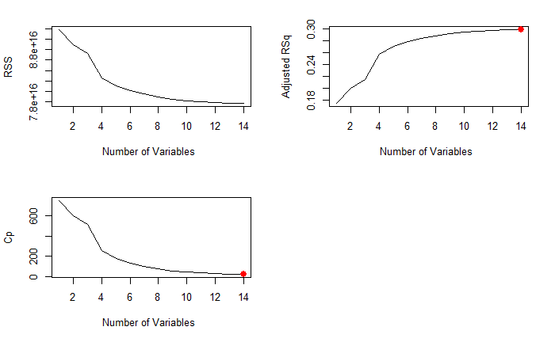

```r
#Backwards stepwise selection
regfit.bwd = regsubsets(salary ~. , data=bstats_salary_numvars,nvmax=13, method ="backward")
```

```
3  linear dependencies found
```

```
Reordering variables and trying again:
```

```r
summary(regfit.bwd)
```

```
Subset selection object
Call: regsubsets.formula(salary ~ ., data = bstats_salary_numvars,
    nvmax = 13, method = "backward")
26 Variables  (and intercept)
           Forced in Forced out
G              FALSE      FALSE
AB             FALSE      FALSE
R              FALSE      FALSE
H              FALSE      FALSE
X2B            FALSE      FALSE
X3B            FALSE      FALSE
HR             FALSE      FALSE
RBI            FALSE      FALSE
SB             FALSE      FALSE
CS             FALSE      FALSE
BB             FALSE      FALSE
SO             FALSE      FALSE
IBB            FALSE      FALSE
HBP            FALSE      FALSE
SH             FALSE      FALSE
SF             FALSE      FALSE
GIDP           FALSE      FALSE
BA             FALSE      FALSE
SlugPct        FALSE      FALSE
OBP            FALSE      FALSE
BABIP          FALSE      FALSE
K_Percent      FALSE      FALSE
BB_Percent     FALSE      FALSE
PA             FALSE      FALSE
TB             FALSE      FALSE
OPS            FALSE      FALSE
1 subsets of each size up to 14
Selection Algorithm: backward
          G   AB  R   H   X2B X3B HR  RBI SB  CS  BB
1  ( 1 )  " " " " " " " " " " " " " " " " " " " " "*"
2  ( 1 )  " " "*" " " " " " " " " " " " " " " " " "*"
3  ( 1 )  "*" "*" " " " " " " " " " " " " " " " " "*"
4  ( 1 )  "*" "*" " " " " " " " " " " " " " " " " "*"
5  ( 1 )  "*" "*" " " " " " " "*" " " " " " " " " "*"
6  ( 1 )  "*" "*" " " " " " " "*" " " " " " " " " "*"
```

[output cut: 23 more lines]

```
          SlugPct OBP OPS BABIP K_Percent BB_Percent
1  ( 1 )  " "     " " " " " "   " "       " "
2  ( 1 )  " "     " " " " " "   " "       " "
3  ( 1 )  " "     " " " " " "   " "       " "
4  ( 1 )  " "     " " " " " "   " "       " "
5  ( 1 )  " "     " " " " " "   " "       " "
6  ( 1 )  " "     " " " " " "   " "       " "
7  ( 1 )  " "     " " " " " "   " "       " "
8  ( 1 )  " "     " " " " " "   " "       " "
9  ( 1 )  "*"     " " " " " "   " "       " "
10  ( 1 ) "*"     " " " " " "   " "       " "
11  ( 1 ) "*"     " " " " " "   " "       " "
12  ( 1 ) "*"     " " " " " "   " "       " "
13  ( 1 ) "*"     " " " " " "   " "       " "
14  ( 1 ) "*"     " " " " "*"   " "       " "
```

```r
reg.summary <- summary(regfit.bwd) #get the summary

par(mfrow=c(2,2))
#rss plot -  NOT USEFUL
plot(reg.summary$rss ,xlab="Number of Variables ",ylab="RSS",type="l")

#adjr2 plot
plot(reg.summary$adjr2 ,xlab="Number of Variables ", ylab="Adjusted RSq",type="l")
```

```r
max_adjr2 <- which.max(reg.summary$adjr2)
points(max_adjr2, reg.summary$adjr2[max_adjr2], col="red", cex=2, pch=20)

# AIC criterion (Cp) to minimize
plot(reg.summary$cp ,xlab="Number of Variables ",ylab="Cp", type='l')
```

```r
min_cp <- which.min(reg.summary$cp )
points(min_cp, reg.summary$cp[min_cp], col="red", cex=2, pch=20)

# BIC criterion to minimize
plot(reg.summary$bic, xlab="Number of Variables ", ylab="BIC", type='l')
```

```r
min_bic <- which.min(reg.summary$bic)
points(min_bic, reg.summary$bic[min_bic], col="red", cex=2, pch=20)
```

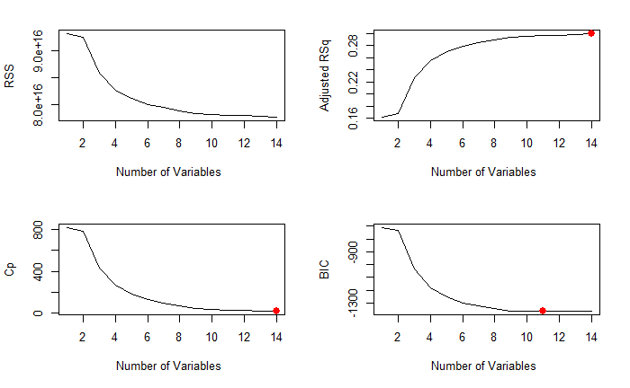

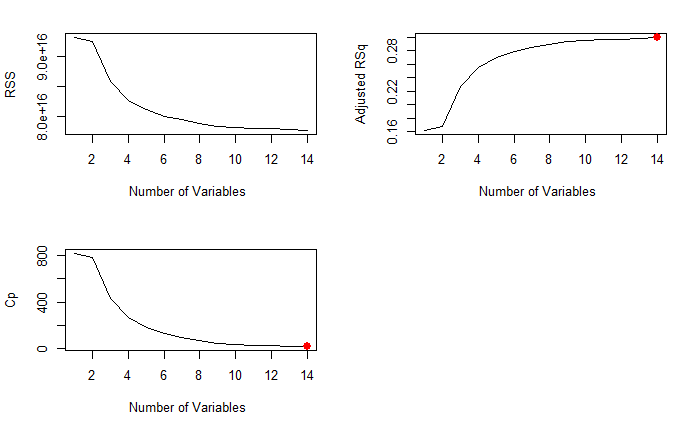

```r
#ridge regression

# getting the predictors
x_var <- bstats_salary_numvars %>% select(-salary) %>% as.matrix()
# getting the independent variable
y_var <- bstats_salary_numvars[,"salary"]
```

```r
ridge <- glmnet(x_var, y_var, alpha=0)
summary(ridge)
```

```
          Length Class     Mode
a0         100   -none-    numeric
beta      2600   dgCMatrix S4
df         100   -none-    numeric
dim          2   -none-    numeric
lambda     100   -none-    numeric
dev.ratio  100   -none-    numeric
nulldev      1   -none-    numeric
npasses      1   -none-    numeric
jerr         1   -none-    numeric
offset       1   -none-    logical
call         4   -none-    call
nobs         1   -none-    numeric
```

```r
cv_ridge <- cv.glmnet(x_var, y_var, alpha = 0)
cv_ridge
```

```
Call:  cv.glmnet(x = x_var, y = y_var, alpha = 0)

Measure: Mean-Squared Error

     Lambda Index   Measure        SE Nonzero
min  216221   100 1.919e+13 5.986e+11      26
1se 1051399    83 1.976e+13 6.505e+11      26
```